# Question

Let’s consider an alternative way to multiply 76 and 48.

First, let’s break each number into its tens and ones.

$$76 ~~=~~ 70+6$$
$$48 ~~=~~ 40+8$$

Now, find all 4 indicated products. Also, find the totals.

| * | $70$ | $6$ | **total** |
| --- | --- | --- | --- |
| $40$ | ##ANSWER1## | ##ANSWER2## | ##ANSWER5## |
| $8$ | ##ANSWER3## | ##ANSWER4## | ##ANSWER6## |
| **total** | ##ANSWER7## | ##ANSWER8## | ##ANSWER9## |

## Answerlist

- 28
- 280
- 2800
- 28000
- 24
- 240
- 2400
- 24000
- 56
- 560
- 5600
- 56000
- 48
- 480
- 4800
- 48000
- 288
- 608
- 3040
- 3360
- 3648
- 288
- 608
- 3040
- 3360
- 3648
- 288
- 608
- 3040
- 3360
- 3648
- 288
- 608
- 3040
- 3360
- 3648
- 288
- 608
- 3040
- 3360
- 3648

# Solution

$$76\cdot 48 = 3648$$

| * | $70$ | $6$ | **total** |
| --- | --- | --- | --- |
| $40$ | 2800 | 240 | 3040 |
| $8$ | 560 | 48 | 608 |
| **total** | 3360 | 288 | 3648 |

At some point I learned about the [multiplication by lines](https://www.mathnstuff.com/math/spoken/here/2class/60/bylines.htm) method. You’ll notice there are 7 lines above 6 lines, both with positive slope. There are also 4 lines above 8 lines, both with negative slope. The number of intersections in the four corners are found with multiplication: $7\cdot4=28$ and $6\cdot4=24$ and $7\cdot8=56$ and $6\cdot8=48$.

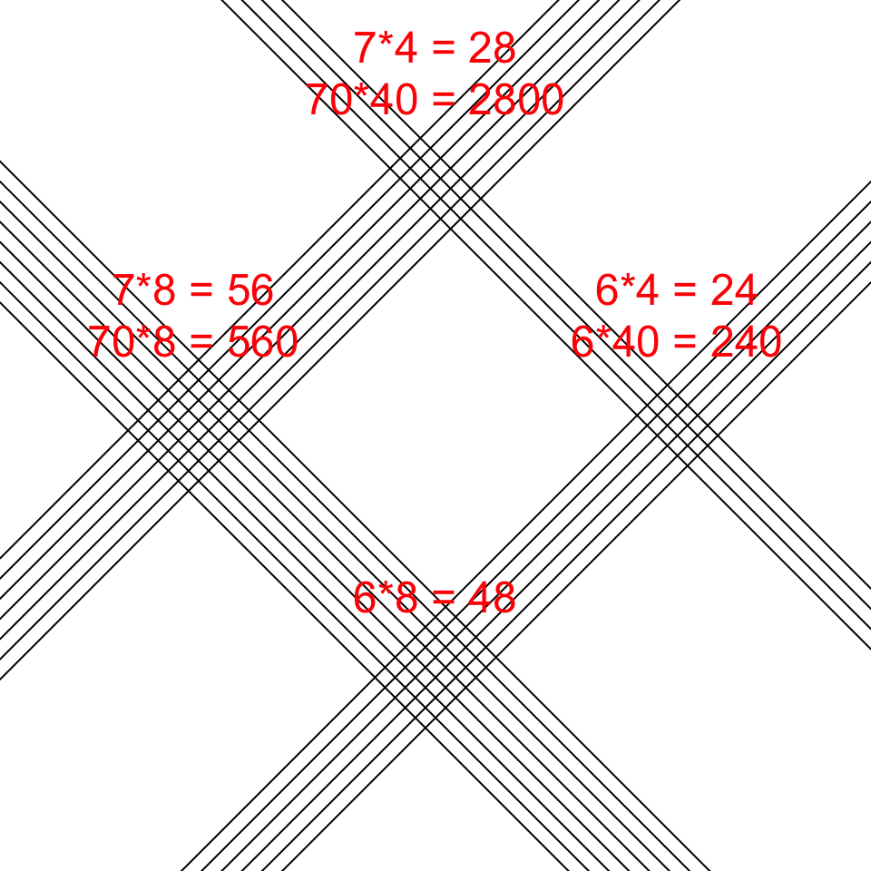

$$2800 + 240 + 560 + 48 ~~=~~
3648$$

# Meta-information

extype: cloze exclozetype: schoice|schoice|schoice|schoice|schoice|schoice|schoice|schoice|schoice exsolution: 0010|0100|0100|1000|00100|01000|00010|10000|00001 exname: multiply_2digits